# INN_Learner_Notebook_Full_code

Bank Churn Prediction

## Problem Statement

### Context

Businesses like banks which provide service have to worry about problem of 'Customer Churn' i.e. customers leaving and joining another service provider. It is important to understand which aspects of the service influence a customer's decision in this regard. Management can concentrate efforts on improvement of service, keeping in mind these priorities.

### Objective

You as a Data scientist with the bank need to build a neural network based classifier that can determine whether a customer will leave the bank or not in the next 6 months.

### Data Dictionary

- CustomerId: Unique ID which is assigned to each customer
- Surname: Last name of the customer
- CreditScore: It defines the credit history of the customer.
- Geography: A customer’s location
- Gender: It defines the Gender of the customer
- Age: Age of the customer
- Tenure: Number of years for which the customer has been with the bank
- NumOfProducts: refers to the number of products that a customer has purchased through the bank.
- Balance: Account balance
- HasCrCard: It is a categorical variable which decides whether the customer has credit card or not.
- EstimatedSalary: Estimated salary
- isActiveMember: Is is a categorical variable which decides whether the customer is active member of the bank or not ( Active member in the sense, using bank products regularly, making transactions etc )
- Exited : whether or not the customer left the bank within six month. It can take two values ** 0=No ( Customer did not leave the bank ) ** 1=Yes ( Customer left the bank )

Disclaimer NOTE: Code blocks seen below are taken from course related primary learning and additional learnng notebooks

**Definition of Problem Statement:**

- The problem faced by the bank is three fold:
- Customer Churn of the bank is at a high enough level that is damaging to the banks top ine revenue generation
- The expenditure taken to prevent churn can become prohibitively leading to loss when taken in the aggregate over time and the percentage of the customer base targeted with rentention tactics
- The efforts needed to prevent churn and/or the potential backlog that prevents the allocation of resources to prevent customer attrition in a timely matter, requires an assessment to be made 6 months in advance, when the transparency of churn and the likelihood of those tactics to succeed can be highly unclear at best still. However, efforts have to be taken at that time as rentention efforts initiated on a short time horizion, say 3 months, may result in lower rentention and higher losses incurred as the offsetting revenue for rentition expenditure is not captured/obtained.

## Importing necessary libraries

```python
# Installing the libraries with the specified version.
!pip install keras-tuner
```

```
Downloading keras_tuner-1.4.7-py3-none-any.whl (129 kB)
   ━━━━━━━━━━━━━━━━━━━━━━━━━━━━━━━━━━━━━━━━ 129.1/129.1 kB 2.8 MB/s eta 0:00:00
Downloading kt_legacy-1.0.5-py3-none-any.whl (9.6 kB)
```

```python
# Libraries to help with reading and manipulating data

import pandas as pd  # Library for data manipulation and analysis.
import numpy as np   # Fundamental package for scientific computing.
import matplotlib.pyplot as plt  # Plotting library for creating visualizations.
import seaborn as sns #For advanced visualizations.

from sklearn.model_selection import train_test_split  # Function for splitting datasets for training and testing.
from sklearn.preprocessing import StandardScaler # For nomralizing the data set to improve ability to use the data within the NN
from sklearn.metrics import accuracy_score, recall_score, precision_score, f1_score

import time  # Module for time-related operations.

import tensorflow as tf #An end-to-end open source machine learning platform
from tensorflow import keras  # High-level neural networks API for deep learning.
from keras_tuner.tuners import RandomSearch  # Hyperparameter tuning for neural networks. # Changed kerastuner to keras_tuner
import keras_tuner as kt # Used to perform Iterative Tuning of the hyperparameters fo the NN's
from keras import backend   # Abstraction layer for neural network backend engines.
from keras.models import Sequential  # Model for building NN sequentially.
from keras.layers import Dense,Dropout,BatchNormalization   # for creating fully connected neural network layers.

import random #Used for number randomization

# importing SMOTE
from imblearn.over_sampling import SMOTE #Used for purposes of balancing the dataset via oversampling

# importing metrics
from sklearn.metrics import confusion_matrix,roc_curve,classification_report,recall_score

import time # To record the start, stop, and differential time taken for the NN to be fit to the training and validation data sets

# Library to avoid the warnings
import warnings
warnings.filterwarnings("ignore")
```

## Loading the dataset

```python
# To mount the Google Drive for purposes of import the dataset from the csv file path called below
from google.colab import drive
drive.mount('/content/drive')
```

```python
# Call of the CSV file with the relevant data set and storage of the data into a dataframe
file_path = '/content/drive/My Drive/ColabNotebooks/Churn.csv'
df = pd.read_csv(file_path)
```

## Data Overview

```python
#Look at first 5 and last 5 rows of the dataframe
print(df.head())
print(df.tail())
#Look at the shape of the dataframe
print(df.shape)
#Look at the data types
print(df.info())
#Review Summary of the Features within the Dataframe
print(df.describe(include = 'all').T)
#Check for null values in each feature
print(df.isnull().sum())
#Find number of Unique values within each feature
print(df.nunique())
```

```
   RowNumber  CustomerId   Surname  CreditScore Geography  Gender  Age  \
0          1    15634602  Hargrave          619    France  Female   42
1          2    15647311      Hill          608     Spain  Female   41
2          3    15619304      Onio          502    France  Female   42
3          4    15701354      Boni          699    France  Female   39
4          5    15737888  Mitchell          850     Spain  Female   43

   Tenure    Balance  NumOfProducts  HasCrCard  IsActiveMember  \
0       2       0.00              1          1               1
1       1   83807.86              1          0               1
2       8  159660.80              3          1               0
3       1       0.00              2          0               0
4       2  125510.82              1          1               1

   EstimatedSalary  Exited
0        101348.88       1
1        112542.58       0
2        113931.57       1
3         93826.63       0
4         79084.10       0
      RowNumber  CustomerId    Surname  CreditScore Geography  Gender  Age  \
9995       9996    15606229   Obijiaku          771    France    Male   39
9996       9997    15569892  Johnstone          516    France    Male   35
9997       9998    15584532        Liu          709    France  Female   36
9998       9999    15682355  Sabbatini          772   Germany    Male   42
9999      10000    15628319     Walker          792    France  Female   28

      Tenure    Balance  NumOfProducts  HasCrCard  IsActiveMember  \
9995       5       0.00              2          1               0
9996      10   57369.61              1          1               1
9997       7       0.00              1          0               1
9998       3   75075.31              2          1               0
9999       4  130142.79              1          1               0

      EstimatedSalary  Exited
9995         96270.64       0
9996        101699.77       0
9997         42085.58       1
9998         92888.52       1
9999         38190.78       0
```

[output cut: 69 more lines]

```
RowNumber          10000
CustomerId         10000
Surname             2932
CreditScore          460
Geography              3
Gender                 2
Age                   70
Tenure                11
Balance             6382
NumOfProducts          4
HasCrCard              2
IsActiveMember         2
EstimatedSalary     9999
Exited                 2
dtype: int64
```

Observations:

- Row Number and CustomerID provide no value and should be removed from the data set via processing
- Estimated Salary and Balance have a high number of unique values, but those numbers are quite reflective of actual real world conditions
- Surname will also have to be dropped as the information gain and resulting insights is bot be worth the conputational resource allocation, especially since those values will have to be encoded leading to roughly 2931 extra feature columns to be added to the dataset!

## Exploratory Data Analysis

**General Note:**

- The 3 features previously mentioned in comments/observations above will not have any uni or bivariate analysis conducted on them below

```python
# function to plot a boxplot and a histogram along the same scale.


def histogram_boxplot(data, feature, figsize=(12, 7), kde=False, bins=None):
    """
    Boxplot and histogram combined

    data: dataframe
    feature: dataframe column
    figsize: size of figure (default (12,7))
    kde: whether to show the density curve (default False)
    bins: number of bins for histogram (default None)
    """
    f2, (ax_box2, ax_hist2) = plt.subplots(
        nrows=2,  # Number of rows of the subplot grid= 2
        sharex=True,  # x-axis will be shared among all subplots
        gridspec_kw={"height_ratios": (0.25, 0.75)},
        figsize=figsize,
    )  # creating the 2 subplots
    sns.boxplot(
        data=data, x=feature, ax=ax_box2, showmeans=True, color="violet"
    )  # boxplot will be created and a star will indicate the mean value of the column
    sns.histplot(
        data=data, x=feature, kde=kde, ax=ax_hist2, bins=bins, palette="winter"
    ) if bins else sns.histplot(
        data=data, x=feature, kde=kde, ax=ax_hist2
    )  # For histogram
    ax_hist2.axvline(
        data[feature].mean(), color="green", linestyle="--"
    )  # Add mean to the histogram
    ax_hist2.axvline(
        data[feature].median(), color="black", linestyle="-"
    )  # Add median to the histogram
```

```python
# function to create labeled barplots


def labeled_barplot(data, feature, perc=False, n=None):
    """
    Barplot with percentage at the top

    data: dataframe
    feature: dataframe column
    perc: whether to display percentages instead of count (default is False)
    n: displays the top n category levels (default is None, i.e., display all levels)
    """

    total = len(data[feature])  # length of the column
    count = data[feature].nunique()
    if n is None:
        plt.figure(figsize=(count + 1, 5))
    else:
        plt.figure(figsize=(n + 1, 5))

    plt.xticks(rotation=90, fontsize=15)
    ax = sns.countplot(
        data=data,
        x=feature,
        palette="Paired",
        order=data[feature].value_counts().index[:n].sort_values(),
    )

    for p in ax.patches:
        if perc == True:
            label = "{:.1f}%".format(
                100 * p.get_height() / total
            )  # percentage of each class of the category
        else:
            label = p.get_height()  # count of each level of the category

        x = p.get_x() + p.get_width() / 2  # width of the plot
        y = p.get_height()  # height of the plot

        ax.annotate(
            label,
            (x, y),
            ha="center",
            va="center",
            size=12,
            xytext=(0, 5),
            textcoords="offset points",
        )  # annotate the percentage

    plt.show()  # show the plot
```

```python
# function to plot stacked bar chart


def stacked_barplot(data, predictor, target):
    """
    Print the category counts and plot a stacked bar chart

    data: dataframe
    predictor: independent variable
    target: target variable
    """
    count = data[predictor].nunique()
    sorter = data[target].value_counts().index[-1]
    tab1 = pd.crosstab(data[predictor], data[target], margins=True).sort_values(
        by=sorter, ascending=False
    )
    print(tab1)
    print("-" * 120)
    tab = pd.crosstab(data[predictor], data[target], normalize="index").sort_values(
        by=sorter, ascending=False
    )
    tab.plot(kind="bar", stacked=True, figsize=(count + 1, 5))
    plt.legend(
        loc="lower left",
        frameon=False,
    )
    plt.legend(loc="upper left", bbox_to_anchor=(1, 1))
    plt.show()
```

```python
### Function to plot distributions


def distribution_plot_wrt_target(data, predictor, target):

    fig, axs = plt.subplots(2, 2, figsize=(12, 10))

    target_uniq = data[target].unique()

    axs[0, 0].set_title("Distribution of target for target=" + str(target_uniq[0]))
    sns.histplot(
        data=data[data[target] == target_uniq[0]],
        x=predictor,
        kde=True,
        ax=axs[0, 0],
        color="teal",
    )

    axs[0, 1].set_title("Distribution of target for target=" + str(target_uniq[1]))
    sns.histplot(
        data=data[data[target] == target_uniq[1]],
        x=predictor,
        kde=True,
        ax=axs[0, 1],
        color="orange",
    )

    axs[1, 0].set_title("Boxplot w.r.t target")
    sns.boxplot(data=data, x=target, y=predictor, ax=axs[1, 0], palette="gist_rainbow")

    axs[1, 1].set_title("Boxplot (without outliers) w.r.t target")
    sns.boxplot(
        data=data,
        x=target,
        y=predictor,
        ax=axs[1, 1],
        showfliers=False,
        palette="gist_rainbow",
    )

    plt.tight_layout()
    plt.show()
```

### Univariate Analysis

#### Observations on CreditScore

- Left Skewed/ outliers on the lower bound
- Mean and Mode at ~650-652

|  | CreditScore |
| --- | --- |
| count | 10000.000000 |
| mean | 650.528800 |
| std | 96.653299 |
| min | 350.000000 |
| 25% | 584.000000 |
| 50% | 652.000000 |
| 75% | 718.000000 |
| max | 850.000000 |

**dtype:** float64

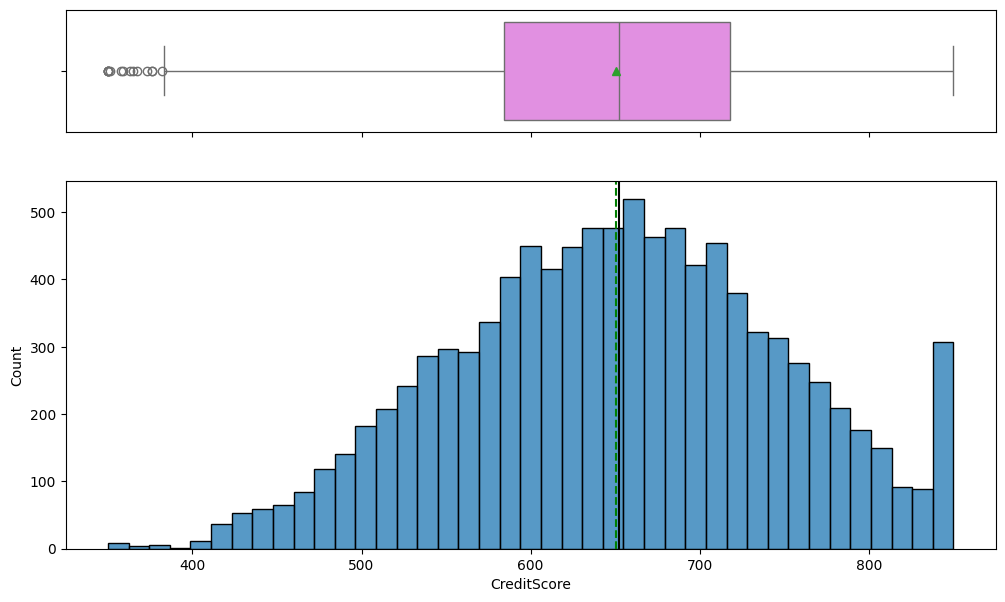

```python
histogram_boxplot(df,'CreditScore')
df['CreditScore'].describe()
```

#### Observations on Age

- Right Skewed/ large number of outliers on the uper bound
- Mean and Mode are at `37-39
- IQR is 32 to 44 years of age

|  | Age |
| --- | --- |
| count | 10000.000000 |
| mean | 38.921800 |
| std | 10.487806 |
| min | 18.000000 |
| 25% | 32.000000 |
| 50% | 37.000000 |
| 75% | 44.000000 |
| max | 92.000000 |

**dtype:** float64

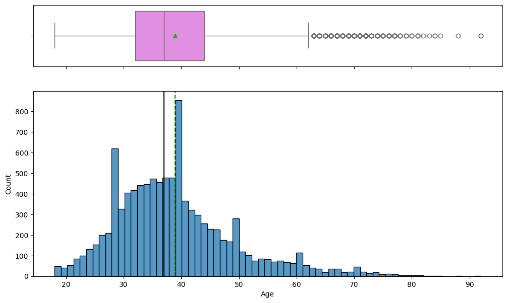

```python
histogram_boxplot(df,'Age')
df['Age'].describe()
```

#### Observations on Balance

|  | Balance |
| --- | --- |
| count | 10000.000000 |
| mean | 76485.889288 |
| std | 62397.405202 |
| min | 0.000000 |
| 25% | 0.000000 |
| 50% | 97198.540000 |
| 75% | 127644.240000 |
| max | 250898.090000 |

**dtype:** float64

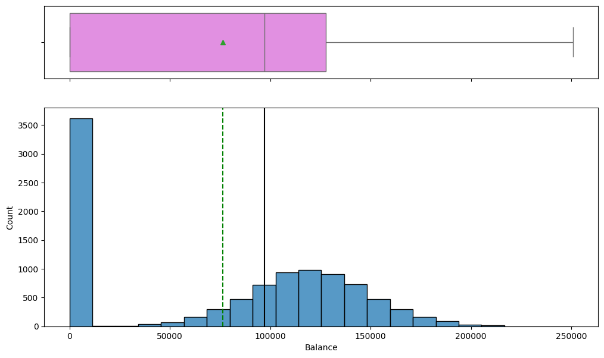

```python
histogram_boxplot(df,'Balance')
df['Balance'].describe()
```

#### Observations on Estimated Salary

- No obvious skewedness/ tails; relaitvely flat/even distribution, all value bins observed are between a count of 400 to 500
- Mean and Mode are at ~ 100100-100200 USD
- IQR is ~51000 to ~149500 USD

|  | EstimatedSalary |
| --- | --- |
| count | 10000.000000 |
| mean | 100090.239881 |
| std | 57510.492818 |
| min | 11.580000 |
| 25% | 51002.110000 |
| 50% | 100193.915000 |
| 75% | 149388.247500 |
| max | 199992.480000 |

**dtype:** float64

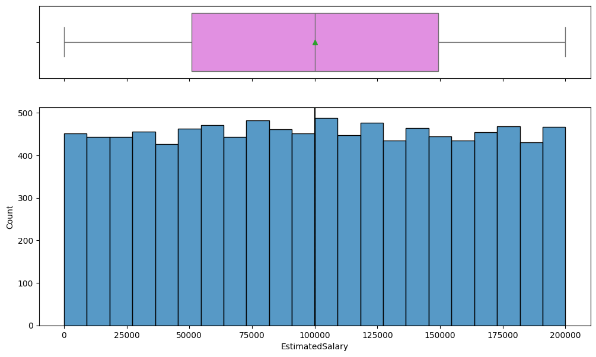

```python
histogram_boxplot(df, 'EstimatedSalary')
df['EstimatedSalary'].describe()
```

#### Observations on Exited

- ~80% of the customers have not exited/stayed as customers at the bank
- ~20% of the customers have exited/churned as customers a the bank

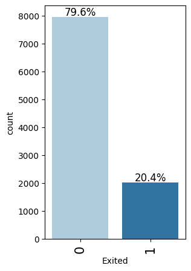

| Exited | count |
| --- | --- |
| 0 | 7963 |
| 1 | 2037 |

**dtype:** int64

```python
labeled_barplot(df, "Exited", perc=True)
df['Exited'].value_counts()
```

#### Observations on Geography

- ~ 50% of clients are located in France
- ~ 25% of clients are located in Germany
- ~ 25% of clients are located in Spain

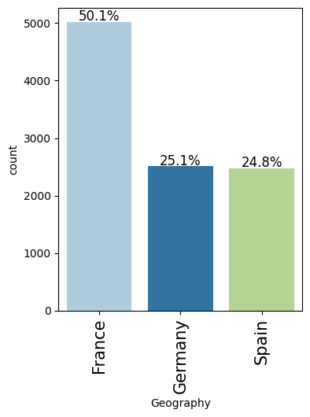

| Geography | count |
| --- | --- |
| France | 5014 |
| Germany | 2509 |
| Spain | 2477 |

**dtype:** int64

```python
labeled_barplot(df, 'Geography', perc=True)
df['Geography'].value_counts()
```

#### Observations on Gender

- ~45% of the clients are women
- ~55% of the clients are men

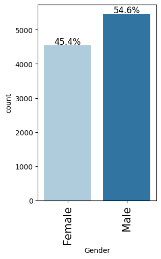

| Gender | count |
| --- | --- |
| Male | 5457 |
| Female | 4543 |

**dtype:** int64

```python
labeled_barplot(df, 'Gender', perc=True)
df['Gender'].value_counts()
```

#### Observations on Tenure

- Each group has ~10% of the overall total, from 1 to 9 Years of Tenure as a Client with the bank; aggregate is ~90%
- The group with 10 years of Tenure at the bank as a client is ~5% of the total
- The group with less than 1 year of tenure at the bank as a client is ~4% of the total

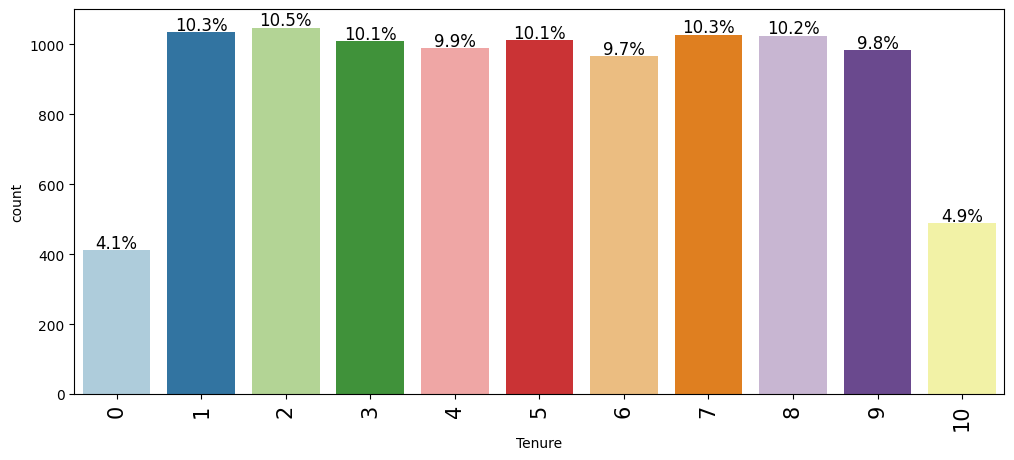

| Tenure | count |
| --- | --- |
| 2 | 1048 |
| 1 | 1035 |
| 7 | 1028 |
| 8 | 1025 |
| 5 | 1012 |
| 3 | 1009 |
| 4 | 989 |
| 9 | 984 |
| 6 | 967 |
| 10 | 490 |
| 0 | 413 |

**dtype:** int64

```python
labeled_barplot(df, 'Tenure', perc=True)
df['Tenure'].value_counts()
```

#### Observations on Number of Products

- ~51% of the clients have 1 product through the bank
- ~46% of the clients have 2 products through the bank
- ~3% of the clients have 3 products through the bank
- <1% of the cleints have 4 products through the bank

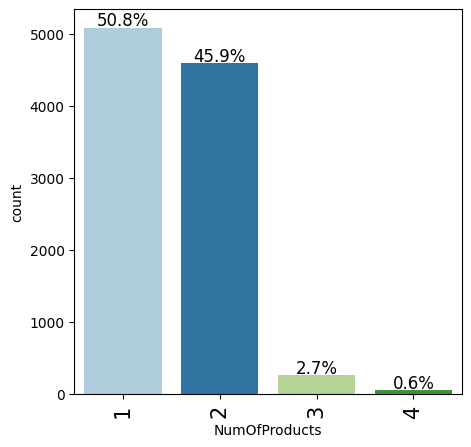

| NumOfProducts | count |
| --- | --- |
| 1 | 5084 |
| 2 | 4590 |
| 3 | 266 |
| 4 | 60 |

**dtype:** int64

```python
labeled_barplot(df, 'NumOfProducts', perc=True)
df['NumOfProducts'].value_counts()
```

#### Observations on Has Credit Card

- ~29% of the clients do not have a Credit Card
- ~71% of the clients do have a Credit Card

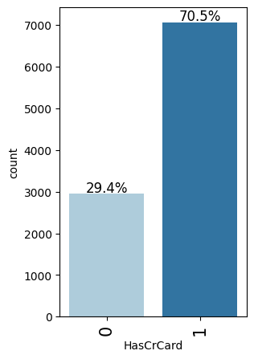

| HasCrCard | count |
| --- | --- |
| 1 | 7055 |
| 0 | 2945 |

**dtype:** int64

```python
labeled_barplot(df, 'HasCrCard', perc=True)
df['HasCrCard'].value_counts()
```

#### Observations on Is Active Member

- ~49% of the clients are defined as "Inactive members" of the bank
- ~51% of the clients are defined as "Active members" of the bank

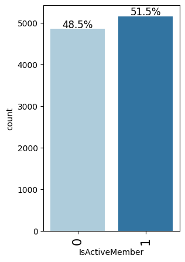

| IsActiveMember | count |
| --- | --- |
| 1 | 5151 |
| 0 | 4849 |

**dtype:** int64

```python
labeled_barplot(df, 'IsActiveMember', perc=True)
df['IsActiveMember'].value_counts()
```

### Bivariate Analysis

#### Observations of the Correlation plot

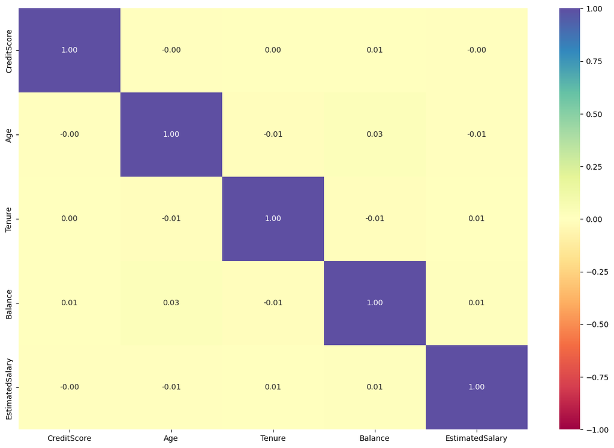

```python
#Create the correlation matrix and heatmap
#NOTE: Given that there are several categorical columns with multiple values, the correlation matrix will only capture the numerical values
#Create a list for only the numerical columns
numcols_list = ["CreditScore","Age","Tenure","Balance","EstimatedSalary"]
plt.figure(figsize=(15, 10))
cm = df[numcols_list].corr()
sns.heatmap(cm, annot=True, vmin=-1, vmax=1, fmt=".2f", cmap="Spectral")
plt.show()
```

#### Observations on Exited Vs Geography

- The percentages of attrition/exited for each client location/geography are as follows:
- Germany: ~35%
- Spain: ~15%
- France: ~15%
- Non-exited/non-attrition is:
- Germany: ~65%
- Spain: ~85%
- France: ~85%

```
Exited        0     1    All
Geography
All        7963  2037  10000
Germany    1695   814   2509
France     4204   810   5014
Spain      2064   413   2477
------------------------------------------------------------------------------------------------------------------------
```

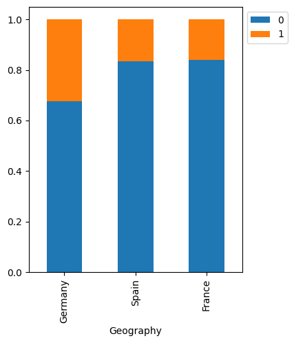

```python
stacked_barplot(df, "Geography", "Exited" )
```

#### Observations on Exited Vs Gender

- The percentages of attrition/exited for each gender are:
- Women: ~25%
- Men: ~15%
- Non-attrition/exited is:
- Women: ~75%
- Men: ~85%

```
Exited     0     1    All
Gender
All     7963  2037  10000
Female  3404  1139   4543
Male    4559   898   5457
------------------------------------------------------------------------------------------------------------------------
```

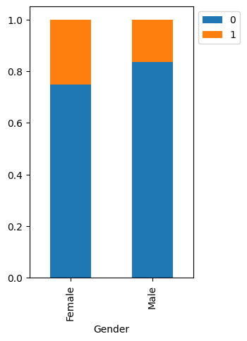

```python
stacked_barplot(df, "Gender", "Exited")
```

#### Observations on Exited Vs Has Credit Card

- The percentages of attrition/exited for has Credit Card are:
- No Credit Card: ~20%
- Credit Card: ~20%
- Non-attrition/exited are:
- No Credit Card: ~80%
- Credit Card: ~80%

```
Exited        0     1    All
HasCrCard
All        7963  2037  10000
1          5631  1424   7055
0          2332   613   2945
------------------------------------------------------------------------------------------------------------------------
```

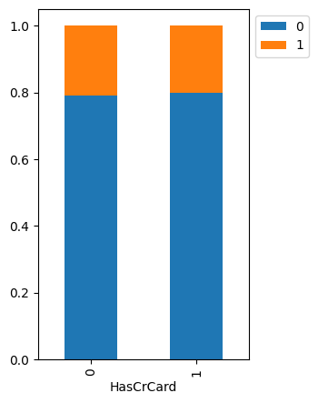

```python
stacked_barplot(df, "HasCrCard", "Exited")
```

#### Observations on Exited Vs Is active member

- The percentages of attrition/exited for is Active Member are:
- Non-Active: ~25%
- Active: ~15%
- Non-attrition/exited are:
- Non-active: ~75%
- Active: ~85%

```
Exited             0     1    All
IsActiveMember
All             7963  2037  10000
0               3547  1302   4849
1               4416   735   5151
------------------------------------------------------------------------------------------------------------------------
```

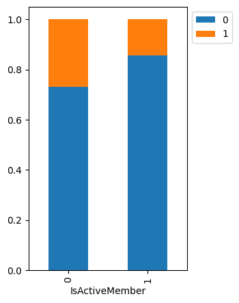

```python
stacked_barplot(df, "IsActiveMember", "Exited")
```

#### Observations on Exited Vs Credit Score

- The distriubution for exited/attrition is a little more left skewed than the ditribution for non-attrition

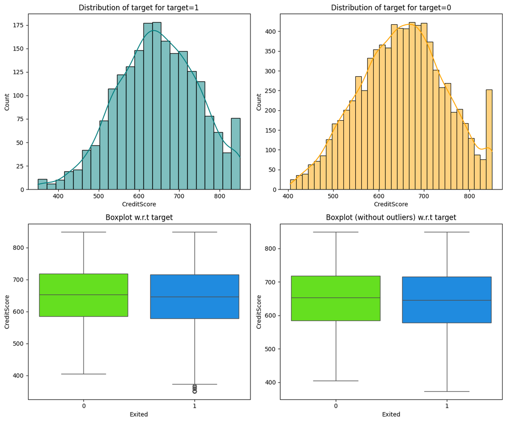

|  | CreditScore |
| --- | --- |
| count | 10000.000000 |
| mean | 650.528800 |
| std | 96.653299 |
| min | 350.000000 |
| 25% | 584.000000 |
| 50% | 652.000000 |
| 75% | 718.000000 |
| max | 850.000000 |

**dtype:** float64

```python
distribution_plot_wrt_target(df, "CreditScore", "Exited")
df["CreditScore"].describe()
```

#### Observations on Exited Vs Age

- The distribution for exited/attrition much less right skewed, actually almost more of perfectly normal distribution comapred to the non-attrtion distribution which is strongly right skewed/has a large number of outliers on the upper bound

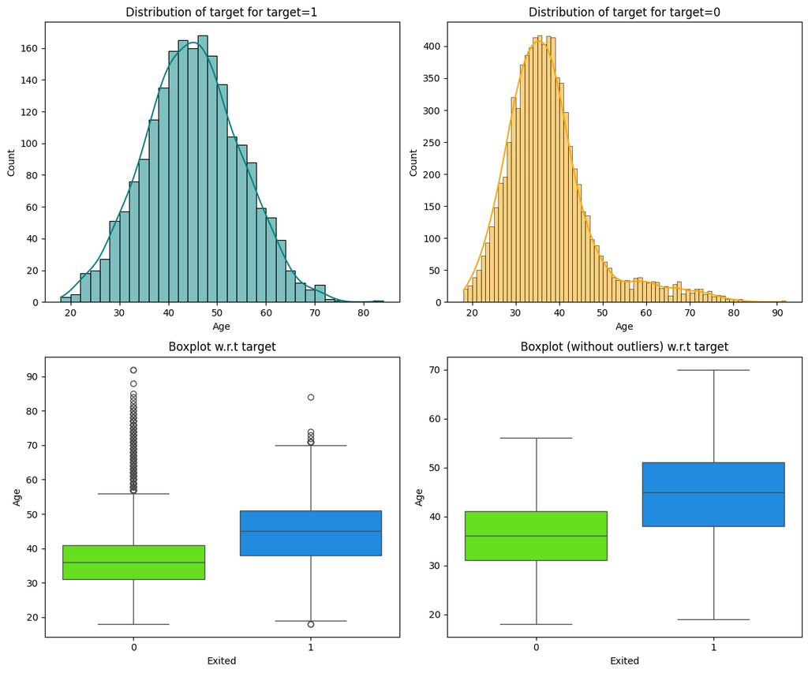

|  | Age |
| --- | --- |
| count | 10000.000000 |
| mean | 38.921800 |
| std | 10.487806 |
| min | 18.000000 |
| 25% | 32.000000 |
| 50% | 37.000000 |
| 75% | 44.000000 |
| max | 92.000000 |

**dtype:** float64

```python
distribution_plot_wrt_target(df, "Age", "Exited")
df["Age"].describe()
```

#### Observations on Exited Vs Tenure

- The distributions for both attrition and non-attrition are fairly identical; only main difference is the overall count in each group

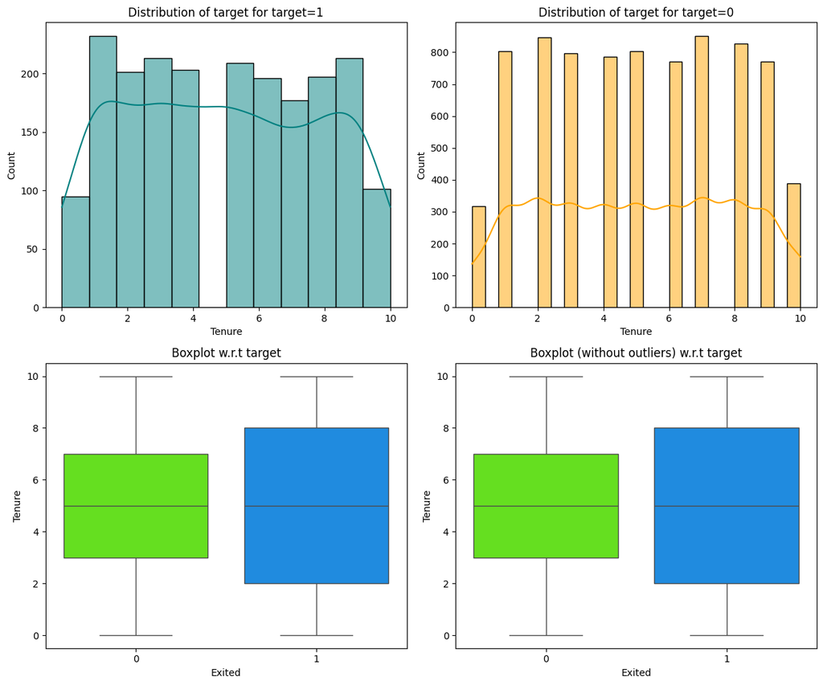

|  | Tenure |
| --- | --- |
| count | 10000.000000 |
| mean | 5.012800 |
| std | 2.892174 |
| min | 0.000000 |
| 25% | 3.000000 |
| 50% | 5.000000 |
| 75% | 7.000000 |
| max | 10.000000 |

**dtype:** float64

```python
distribution_plot_wrt_target(df, "Tenure", "Exited")
df["Tenure"].describe()
```

#### Observations on Exited Vs Balance

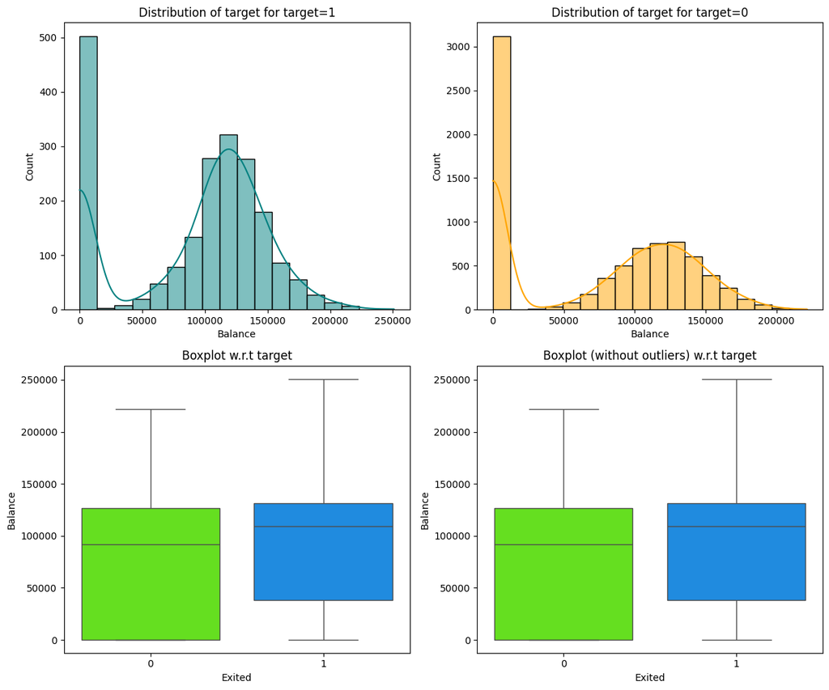

|  | Balance |
| --- | --- |
| count | 10000.000000 |
| mean | 76485.889288 |
| std | 62397.405202 |
| min | 0.000000 |
| 25% | 0.000000 |
| 50% | 97198.540000 |
| 75% | 127644.240000 |
| max | 250898.090000 |

**dtype:** float64

```python
distribution_plot_wrt_target(df, "Balance", "Exited")
df["Balance"].describe()
```

#### Observations on Exited Vs Number of Products

- Attrition is overwhelmingly highest for 1 product had, followed by 2, 3 and 4 products respectively
- Non-attrition is highest for 2 products had followed closely behind by 1 product and then a far distant 3 products had. interestingly noone in the non-attrition group had 4 products

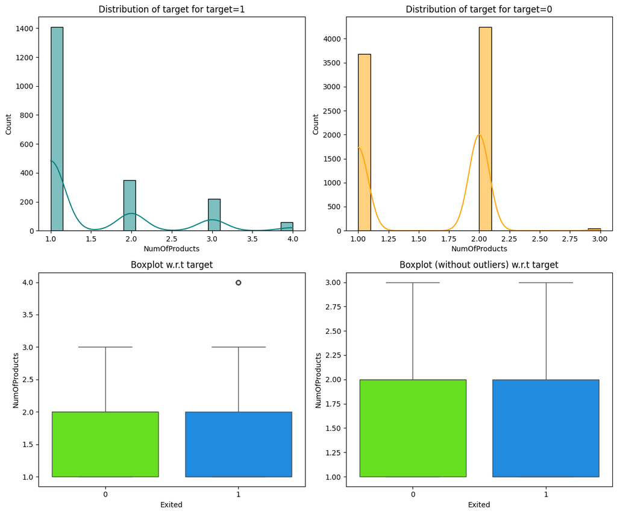

|  | NumOfProducts |
| --- | --- |
| count | 10000.000000 |
| mean | 1.530200 |
| std | 0.581654 |
| min | 1.000000 |
| 25% | 1.000000 |
| 50% | 1.000000 |
| 75% | 2.000000 |
| max | 4.000000 |

**dtype:** float64

```python
distribution_plot_wrt_target(df, "NumOfProducts", "Exited")
df["NumOfProducts"].describe()
```

#### Observations on Exited Vs Estimated Salary

- The distributions for both attrition and non-attrition are fairly indentical; the only main difference is the overall count in each group

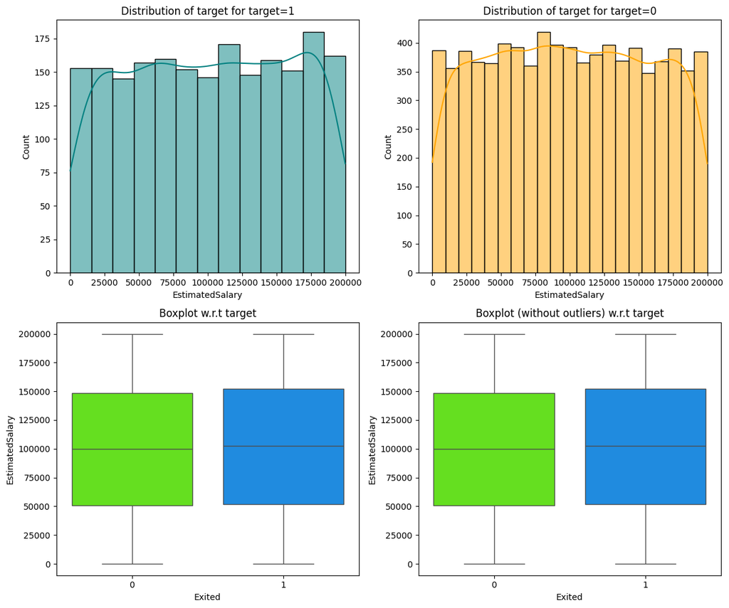

|  | EstimatedSalary |
| --- | --- |
| count | 10000.000000 |
| mean | 100090.239881 |
| std | 57510.492818 |
| min | 11.580000 |
| 25% | 51002.110000 |
| 50% | 100193.915000 |
| 75% | 149388.247500 |
| max | 199992.480000 |

**dtype:** float64

```python
distribution_plot_wrt_target(df, "EstimatedSalary", "Exited")
df['EstimatedSalary'].describe()
```

## Data Preprocessing

### Dummy Variable Creation

```python
#Create a copy of the original Dataframe
df1 = df.copy()
#Reinitializing list of numerical value columens
numcols_list = ["CreditScore","Age","Tenure","Balance","EstimatedSalary"]
# Dropping RowNumber, CustomerId and Surname as they do not add value from an analytical standpoint as previously mentioned in observations and comments
df1 = df1.drop(['RowNumber', 'CustomerId', 'Surname'], axis=1)
#Create dummy variables for columns that are non-numeric or object designated
df1 = pd.get_dummies(df1,columns=df1.select_dtypes(include=["object"]).columns.tolist(),drop_first=True)
#Convert dummy variables to floating point numerical
df1 = df1.astype(float)
#Re-check of first 5 rows of the dataframe
df1.head()
```

|  | CreditScore | Age | Tenure | Balance | NumOfProducts | HasCrCard | IsActiveMember | EstimatedSalary | Exited | Geography_Germany | Geography_Spain | Gender_Male |
| --- | --- | --- | --- | --- | --- | --- | --- | --- | --- | --- | --- | --- |
| 0 | 619.0 | 42.0 | 2.0 | 0.00 | 1.0 | 1.0 | 1.0 | 101348.88 | 1.0 | 0.0 | 0.0 | 0.0 |
| 1 | 608.0 | 41.0 | 1.0 | 83807.86 | 1.0 | 0.0 | 1.0 | 112542.58 | 0.0 | 0.0 | 1.0 | 0.0 |
| 2 | 502.0 | 42.0 | 8.0 | 159660.80 | 3.0 | 1.0 | 0.0 | 113931.57 | 1.0 | 0.0 | 0.0 | 0.0 |
| 3 | 699.0 | 39.0 | 1.0 | 0.00 | 2.0 | 0.0 | 0.0 | 93826.63 | 0.0 | 0.0 | 0.0 | 0.0 |
| 4 | 850.0 | 43.0 | 2.0 | 125510.82 | 1.0 | 1.0 | 1.0 | 79084.10 | 0.0 | 0.0 | 1.0 | 0.0 |

### Train-validation-test Split

```python
#Defining Input and Output Dataframe
X = df1.drop(['Exited'],axis=1)
y = df1['Exited']

#Recheck the percentage breakdown of the Exited to non-Exited classes with the feature.
y.value_counts(normalize=True)
```

| Exited | proportion |
| --- | --- |
| 0.0 | 0.7963 |
| 1.0 | 0.2037 |

**dtype:** float64

- As previously mentioned the class split is ~80% non-attrition and ~20% attrition

```python
# Splitting the dataset into the Training and Testing set.
X_temp, X_test, y_temp, y_test = train_test_split(X, y, test_size = 0.2, random_state = 13) #,stratify=y,shuffle = True
# Splitting the dataset into the Training and Testing set.

X_train, X_val, y_train, y_val = train_test_split(X_temp, y_temp, test_size = 0.2, random_state = 13) #,stratify=y_temo, shuffle = True

#Print Shape of the Inputs
print(X_train.shape, X_val.shape, X_test.shape)

#Print Shapes of the Outputs
print(y_train.shape, y_val.shape, y_test.shape)
#Verify class split of the training, validation, and test set outputs
print(y_train.value_counts(normalize=True))
print(y_val.value_counts(normalize=True))
print(y_test.value_counts(normalize=True))
```

```
(6400, 11) (1600, 11) (2000, 11)
(6400,) (1600,) (2000,)
Exited
0.0    0.796094
1.0    0.203906
Name: proportion, dtype: float64
Exited
0.0    0.795625
1.0    0.204375
Name: proportion, dtype: float64
Exited
0.0    0.7975
1.0    0.2025
Name: proportion, dtype: float64
```

- The Training, Validation, and Test set data maintains the same class breakdown for exited and non-exited

### Data Normalization

```python
#Create Scaler
scale = StandardScaler()
#Transform and fit data to that scaler created
X_train[numcols_list] = scale.fit_transform(X_train[numcols_list])
X_val[numcols_list] = scale.transform(X_val[numcols_list])
X_test[numcols_list] = scale.transform(X_test[numcols_list])
```

## Model Building

### Model Evaluation Criterion

**Write down the logic for choosing the metric that would be the best metric for this business scenario.**

- **The best metric to use in this business scenario is Recall**. Accuracy is also of strong importance to ensure proper fit, so it will be tracked.
- The reason Recall is the best metric is because as a business, the bank is trying to predict the probability of churn in the client base and prevent that churn as much as possible as that churn is equivalent to revenue loss.
- Now there are levels of willingness to pay for rentention efforts, as customer aqusition cost, customer support cost, and customer rentention cost in aggregate can put a bank into receiving a negative customer lifetime value at an indiviual level, and a negative profit margin,if not managed logically and within bounds of churn tolerance, due to the higher operational expinditure associated at the enterprise scale level due to the large client base.

**Let's create a function for plotting the confusion matrix**

```python
def make_confusion_matrix(actual_targets, predicted_targets):
    """
    To plot the confusion_matrix with percentages

    actual_targets: actual target (dependent) variable values
    predicted_targets: predicted target (dependent) variable values
    """
    cm = confusion_matrix(actual_targets, predicted_targets)
    labels = np.asarray(
        [
            ["{0:0.0f}".format(item) + "\n{0:.2%}".format(item / cm.flatten().sum())]
            for item in cm.flatten()
        ]
    ).reshape(cm.shape[0], cm.shape[1])

    plt.figure(figsize=(6, 4))
    sns.heatmap(cm, annot=labels, fmt="")
    plt.ylabel("True label")
    plt.xlabel("Predicted label")
```

```python
def plot(history, name):
    """
    Function to plot loss/accuracy

    history: an object which stores the metrics and losses.
    name: can be one of Loss or Accuracy
    """
    fig, ax = plt.subplots() #Creating a subplot with figure and axes.
    plt.plot(history.history[name]) #Plotting the train performance metric or train loss
    plt.plot(history.history['val_'+name]) #Plotting the validation performance metric or validation loss

    plt.title('Model ' + name.capitalize()) #Defining the title of the plot.
    plt.ylabel(name.capitalize()) #Capitalizing the first letter.
    plt.xlabel('Epoch') #Defining the label for the x-axis.
    fig.legend(['Train', 'Validation'], loc="outside right upper") #Defining the legend, loc controls the position of the legend.
```

```python
# defining a function to compute different metrics to check performance of a classification model built using statsmodels
def model_performance_classification(
    model, predictors, target, threshold=0.5
):
    """
    Function to compute different metrics to check classification model performance

    model: classifier
    predictors: independent variables
    target: dependent variable
    threshold: threshold for classifying the observation as class 1
    """

    # checking which probabilities are greater than threshold
    pred = model.predict(predictors) > threshold


    accuracy = accuracy_score(target, pred)  # to compute Accuracy
    recall = recall_score(target, pred, average='weighted')  # to compute Recall
    precision = precision_score(target, pred, average='weighted')  # to compute Precision
    f1 = f1_score(target, pred, average='weighted')  # to compute F1-score

    # creating a dataframe of metrics
    df_perf = pd.DataFrame(
        {"Accuracy": accuracy, "Recall": recall, "Precision": precision, "F1 Score": f1,},
        index=[0],
    )

    return df_perf
```

### Initial Model Set-Up

Set up of performance and parameters dataframe for comparison of optimal model ultiimately chosen

```python
#Create a dataframe to store the results from all the models we build
#Defining the columns of the dataframe which are nothing but the hyper parameters and the metrics.
columns = ["# neurons - input layer","activation function - input layer","# hidden layers","# neurons - hidden layer","activation function - hidden layer ","# epochs","batch size","optimizer","learning rate", "momentum","weight initializer","regularization","train loss","validation loss","train accuracy","validation accuracy","train recall", "validation recall", "recall diff", "time (secs)"]

#Creating a pandas dataframe.
results = pd.DataFrame(columns=columns)
```

```python
#Creating a pandas dataframe.
subresults = pd.DataFrame(columns=columns)
```

#### Neural Network with SGD Optimizer Model_0A/ Manual Tuning

Initial Set Up of the Batch Size and Epochs Variables

```python
#Initialize batch size and epochs with each run; will update here if needed to optimize later on
batch_size = 32
epochs = 100
```

```python
# clears the current Keras session, resetting all layers and models previously created, freeing up memory and resources.
tf.keras.backend.clear_session()
#Sets the starting point/seed for every NN model built
np.random.seed()
random.seed()
tf.random.set_seed(13)
```

```python
#Initializing the neural network
model_0A = Sequential()
# Adding the input layer with 64 neurons and relu as activation function
model_0A.add(Dense(64, activation='relu', input_dim = X_train.shape[1]))
# Adding the hidden layer with 64 neurons and relu activation function
model_0A.add(Dense(64, activation='relu'))
# Addin output layer with 1 nueron and sigmoid activation function
model_0A.add(Dense(1, activation = 'sigmoid'))
```

```python
#Intiate the Optimizer with desired learning rate
optimizer = tf.keras.optimizers.SGD(learning_rate=0.001)

# Metric of Signinificance to track is Recall
metricA = 'accuracy'
metricR = 'recall'
```

```python
#Compile the model with binary cross entropy as loss function and accuracy and recall as the metrics.
model_0A.compile(loss='binary_crossentropy',optimizer=optimizer, metrics = [metricA, metricR])
```

Base Model Key Parameters chosen for manual tuning

```python
#Print a summary of the key parameters of the NN model created
model_0A.summary()
```

```
Model: "sequential"
```

```
┏━━━━━━━━━━━━━━━━━━━━━━━━━━━━━━━━━━━━━━┳━━━━━━━━━━━━━━━━━━━━━━━━━━━━━┳━━━━━━━━━━━━━━━━━┓
┃ Layer (type)                         ┃ Output Shape                ┃         Param # ┃
┡━━━━━━━━━━━━━━━━━━━━━━━━━━━━━━━━━━━━━━╇━━━━━━━━━━━━━━━━━━━━━━━━━━━━━╇━━━━━━━━━━━━━━━━━┩
│ dense (Dense)                        │ (None, 64)                  │             768 │
├──────────────────────────────────────┼─────────────────────────────┼─────────────────┤
│ dense_1 (Dense)                      │ (None, 64)                  │           4,160 │
├──────────────────────────────────────┼─────────────────────────────┼─────────────────┤
│ dense_2 (Dense)                      │ (None, 1)                   │              65 │
└──────────────────────────────────────┴─────────────────────────────┴─────────────────┘
```

```
 Total params: 4,993 (19.50 KB)
```

```
 Trainable params: 4,993 (19.50 KB)
```

```
 Non-trainable params: 0 (0.00 B)
```

```python
#Running the Fit of the NN on the Train and Validation  Data and tracking the time taken
start = time.time()

history_0A = model_0A.fit(
    X_train, y_train,
    batch_size= batch_size,
    validation_data=(X_val,y_val),
    epochs= epochs,
    verbose=1
)
end = time.time()
tt = end-start
print(f"Total training time: {tt} seconds")
```

```
200/200 ━━━━━━━━━━━━━━━━━━━━ 1s 3ms/step - accuracy: 0.7416 - loss: 0.6126 - recall: 0.1803 - val_accuracy: 0.7862 - val_loss: 0.5754 - val_recall: 0.0489
200/200 ━━━━━━━━━━━━━━━━━━━━ 1s 2ms/step - accuracy: 0.7957 - loss: 0.5554 - recall: 0.0472 - val_accuracy: 0.7950 - val_loss: 0.5426 - val_recall: 0.0122
200/200 ━━━━━━━━━━━━━━━━━━━━ 1s 2ms/step - accuracy: 0.7990 - loss: 0.5246 - recall: 0.0155 - val_accuracy: 0.7956 - val_loss: 0.5245 - val_recall: 0.0061
200/200 ━━━━━━━━━━━━━━━━━━━━ 0s 2ms/step - accuracy: 0.7999 - loss: 0.5071 - recall: 0.0086 - val_accuracy: 0.7956 - val_loss: 0.5136 - val_recall: 0.0031
200/200 ━━━━━━━━━━━━━━━━━━━━ 1s 2ms/step - accuracy: 0.7998 - loss: 0.4963 - recall: 0.0082 - val_accuracy: 0.7962 - val_loss: 0.5062 - val_recall: 0.0031
200/200 ━━━━━━━━━━━━━━━━━━━━ 1s 2ms/step - accuracy: 0.7997 - loss: 0.4890 - recall: 0.0066 - val_accuracy: 0.7962 - val_loss: 0.5005 - val_recall: 0.0031
200/200 ━━━━━━━━━━━━━━━━━━━━ 1s 2ms/step - accuracy: 0.7997 - loss: 0.4835 - recall: 0.0066 - val_accuracy: 0.7956 - val_loss: 0.4958 - val_recall: 0.0031
200/200 ━━━━━━━━━━━━━━━━━━━━ 1s 2ms/step - accuracy: 0.7998 - loss: 0.4790 - recall: 0.0071 - val_accuracy: 0.7962 - val_loss: 0.4916 - val_recall: 0.0061
200/200 ━━━━━━━━━━━━━━━━━━━━ 0s 2ms/step - accuracy: 0.8001 - loss: 0.4751 - recall: 0.0087 - val_accuracy: 0.7962 - val_loss: 0.4878 - val_recall: 0.0061
200/200 ━━━━━━━━━━━━━━━━━━━━ 1s 2ms/step - accuracy: 0.8001 - loss: 0.4717 - recall: 0.0093 - val_accuracy: 0.7956 - val_loss: 0.4842 - val_recall: 0.0061
200/200 ━━━━━━━━━━━━━━━━━━━━ 1s 2ms/step - accuracy: 0.8001 - loss: 0.4685 - recall: 0.0102 - val_accuracy: 0.7969 - val_loss: 0.4808 - val_recall: 0.0122
200/200 ━━━━━━━━━━━━━━━━━━━━ 1s 3ms/step - accuracy: 0.7993 - loss: 0.4657 - recall: 0.0109 - val_accuracy: 0.7975 - val_loss: 0.4776 - val_recall: 0.0153
200/200 ━━━━━━━━━━━━━━━━━━━━ 1s 3ms/step - accuracy: 0.7986 - loss: 0.4630 - recall: 0.0109 - val_accuracy: 0.7975 - val_loss: 0.4747 - val_recall: 0.0153
200/200 ━━━━━━━━━━━━━━━━━━━━ 1s 3ms/step - accuracy: 0.7985 - loss: 0.4606 - recall: 0.0129 - val_accuracy: 0.7969 - val_loss: 0.4719 - val_recall: 0.0183
200/200 ━━━━━━━━━━━━━━━━━━━━ 1s 3ms/step - accuracy: 0.7987 - loss: 0.4583 - recall: 0.0193 - val_accuracy: 0.7956 - val_loss: 0.4693 - val_recall: 0.0183
200/200 ━━━━━━━━━━━━━━━━━━━━ 1s 3ms/step - accuracy: 0.7977 - loss: 0.4562 - recall: 0.0221 - val_accuracy: 0.7956 - val_loss: 0.4668 - val_recall: 0.0245
200/200 ━━━━━━━━━━━━━━━━━━━━ 1s 2ms/step - accuracy: 0.7980 - loss: 0.4542 - recall: 0.0288 - val_accuracy: 0.7944 - val_loss: 0.4645 - val_recall: 0.0306
200/200 ━━━━━━━━━━━━━━━━━━━━ 1s 2ms/step - accuracy: 0.7979 - loss: 0.4524 - recall: 0.0320 - val_accuracy: 0.7937 - val_loss: 0.4624 - val_recall: 0.0336
200/200 ━━━━━━━━━━━━━━━━━━━━ 1s 2ms/step - accuracy: 0.7973 - loss: 0.4507 - recall: 0.0337 - val_accuracy: 0.7944 - val_loss: 0.4604 - val_recall: 0.0428
200/200 ━━━━━━━━━━━━━━━━━━━━ 1s 2ms/step - accuracy: 0.7970 - loss: 0.4491 - recall: 0.0395 - val_accuracy: 0.7962 - val_loss: 0.4585 - val_recall: 0.0520
200/200 ━━━━━━━━━━━━━━━━━━━━ 1s 2ms/step - accuracy: 0.7966 - loss: 0.4477 - recall: 0.0422 - val_accuracy: 0.7962 - val_loss: 0.4568 - val_recall: 0.0581
200/200 ━━━━━━━━━━━━━━━━━━━━ 1s 2ms/step - accuracy: 0.7964 - loss: 0.4463 - recall: 0.0469 - val_accuracy: 0.7962 - val_loss: 0.4551 - val_recall: 0.0612
200/200 ━━━━━━━━━━━━━━━━━━━━ 0s 2ms/step - accuracy: 0.7951 - loss: 0.4450 - recall: 0.0481 - val_accuracy: 0.7981 - val_loss: 0.4536 - val_recall: 0.0734
200/200 ━━━━━━━━━━━━━━━━━━━━ 0s 2ms/step - accuracy: 0.7972 - loss: 0.4439 - recall: 0.0606 - val_accuracy: 0.7969 - val_loss: 0.4521 - val_recall: 0.0765
200/200 ━━━━━━━━━━━━━━━━━━━━ 0s 2ms/step - accuracy: 0.7979 - loss: 0.4427 - recall: 0.0679 - val_accuracy: 0.7969 - val_loss: 0.4507 - val_recall: 0.0826
200/200 ━━━━━━━━━━━━━━━━━━━━ 1s 2ms/step - accuracy: 0.7991 - loss: 0.4417 - recall: 0.0769 - val_accuracy: 0.7987 - val_loss: 0.4494 - val_recall: 0.0979
```

[output cut: 75 more lines]

```python
#Performance Table on the model
model_performance_classification(model_0A, X_train, y_train)
```

```
200/200 ━━━━━━━━━━━━━━━━━━━━ 0s 2ms/step
```

|  | Accuracy | Recall | Precision | F1 Score |
| --- | --- | --- | --- | --- |
| 0 | 0.819219 | 0.819219 | 0.796747 | 0.782729 |

```python
#Performance Table on the model
model_performance_classification(model_0A, X_val, y_val)
```

```
50/50 ━━━━━━━━━━━━━━━━━━━━ 0s 2ms/step
```

|  | Accuracy | Recall | Precision | F1 Score |
| --- | --- | --- | --- | --- |
| 0 | 0.823125 | 0.823125 | 0.802872 | 0.790356 |

SubResults Table

Base Model Key Parameters chosen for manual tuning

- Batch Size 32
- Epochs 100
- Input Layer: 64 Neurons, Relu Activation
- Hidden Layer 1: 64 Neurons, Relu Activation
- Output Layer: 1 Neuron, Sigmoid Activation
- Optimizer: SGD, Learning Rate: 0.001
- Loss Function: Binary Cross Entropy

```python
# #Clear subresults index to update parameters information
# subresults.drop(subresults.index[0], inplace=True)
#Enter in new parameter and performance information
subresults.loc[0] = [64, "relu", 1, 64, "relu", 100, 32, "sgd", 0.001, "-", "xavier", "-",
          history_0A.history["loss"][-1], history_0A.history["val_loss"][-1],
          history_0A.history["accuracy"][-1], history_0A.history["val_accuracy"][-1], history_0A.history['recall'][-1],
          history_0A.history['val_recall'][-1], history_0A.history['recall'][-1] - history_0A.history['val_recall'][-1],
          round(tt, 2)]
subresults
```

|  | # neurons - input layer | activation function - input layer | # hidden layers | # neurons - hidden layer | activation function - hidden layer | # epochs | batch size | optimizer | learning rate | momentum | weight initializer | regularization | train loss | validation loss | train accuracy | validation accuracy | train recall | validation recall | recall diff | time (secs) |
| --- | --- | --- | --- | --- | --- | --- | --- | --- | --- | --- | --- | --- | --- | --- | --- | --- | --- | --- | --- | --- |
| 0 | 64 | relu | 1 | 64 | relu | 100 | 32 | sgd | 0.001 | - | xavier | - | 0.410786 | 0.418288 | 0.819687 | 0.823125 | 0.230651 | 0.259939 | -0.029288 | 78.25 |